## Session 3: EURODOL (non-Seasonal) ARIMA(p,d,q) Modelling

### Aim: To identify (and fit) at least 2 plausible non-Seasonal ARIMA(p,d,q) models for the EURODOL time series

#### EURODOL: Exchange rate; US dollars per euro or ECU (USD / EUR). January 1995 - December 2019; 25 years. Data source: official web Banco de España (https://www.bde.es/webbde/es/estadis/infoest/tipos/tipos.html).

### I. Exploratory data analysis

Import the data

```r
serie=ts((read.table("eurodol.dat")),start=1995,freq=12)
print(round(serie,3))
```

```
##        Jan   Feb   Mar   Apr   May   Jun   Jul   Aug   Sep   Oct   Nov   Dec
## 1995 1.241 1.259 1.317 1.341 1.322 1.331 1.345 1.304 1.289 1.322 1.324 1.304
## 1996 1.292 1.289 1.281 1.264 1.247 1.253 1.271 1.283 1.269 1.258 1.277 1.250
## 1997 1.216 1.166 1.150 1.145 1.149 1.137 1.105 1.073 1.100 1.120 1.139 1.112
## 1998 1.088 1.088 1.084 1.091 1.109 1.101 1.097 1.102 1.154 1.194 1.164 1.172
## 1999 1.161 1.121 1.088 1.070 1.063 1.038 1.035 1.060 1.050 1.071 1.034 1.011
## 2000 1.014 0.983 0.964 0.947 0.906 0.949 0.940 0.904 0.872 0.855 0.856 0.897
## 2001 0.938 0.922 0.910 0.892 0.874 0.853 0.861 0.900 0.911 0.906 0.888 0.892
## 2002 0.883 0.870 0.876 0.886 0.917 0.955 0.992 0.978 0.981 0.981 1.001 1.018
## 2003 1.062 1.077 1.081 1.085 1.158 1.166 1.137 1.114 1.122 1.169 1.170 1.229
## 2004 1.261 1.265 1.226 1.199 1.201 1.214 1.227 1.218 1.222 1.249 1.299 1.341
## 2005 1.312 1.301 1.320 1.294 1.269 1.216 1.204 1.229 1.226 1.201 1.179 1.186
## 2006 1.210 1.194 1.202 1.227 1.277 1.265 1.268 1.281 1.273 1.261 1.288 1.321
## 2007 1.300 1.307 1.324 1.352 1.351 1.342 1.372 1.362 1.390 1.423 1.468 1.457
## 2008 1.472 1.475 1.553 1.575 1.556 1.555 1.577 1.498 1.437 1.332 1.273 1.345
## 2009 1.324 1.278 1.305 1.319 1.365 1.402 1.409 1.427 1.456 1.482 1.491 1.461
## 2010 1.427 1.369 1.357 1.341 1.257 1.221 1.277 1.289 1.307 1.390 1.366 1.322
## 2011 1.336 1.365 1.400 1.444 1.435 1.439 1.426 1.434 1.377 1.371 1.356 1.318
## 2012 1.290 1.322 1.320 1.316 1.279 1.253 1.229 1.240 1.286 1.297 1.283 1.312
## 2013 1.329 1.336 1.296 1.303 1.298 1.319 1.308 1.331 1.335 1.363 1.349 1.370
## 2014 1.361 1.366 1.382 1.381 1.373 1.359 1.354 1.332 1.290 1.267 1.247 1.233
## 2015 1.162 1.135 1.084 1.078 1.115 1.121 1.100 1.114 1.122 1.124 1.074 1.088
## 2016 1.086 1.109 1.110 1.134 1.131 1.123 1.107 1.121 1.121 1.103 1.080 1.054
## 2017 1.061 1.064 1.068 1.072 1.106 1.123 1.151 1.181 1.191 1.176 1.174 1.184
## 2018 1.220 1.235 1.234 1.228 1.181 1.168 1.169 1.155 1.166 1.148 1.137 1.138
## 2019 1.142 1.135 1.130 1.124 1.118 1.129 1.122 1.113 1.100 1.105 1.105 1.111
```

Plot the time series EURODOL; describe it…

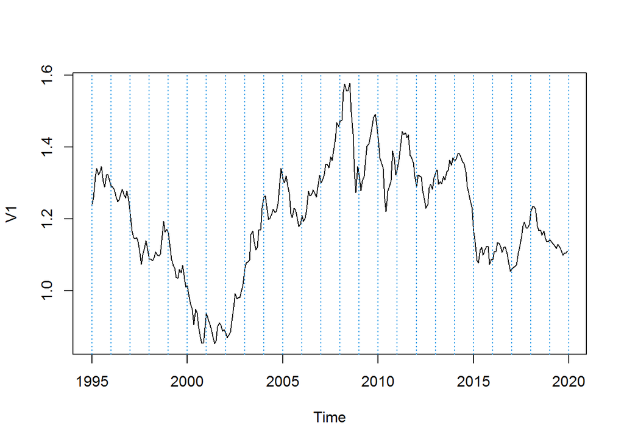

```r
plot(serie)
abline(v=1995:2020,col=4,lty=3)
```

### II. Transformation into stationarity

**Is Variance constant?**

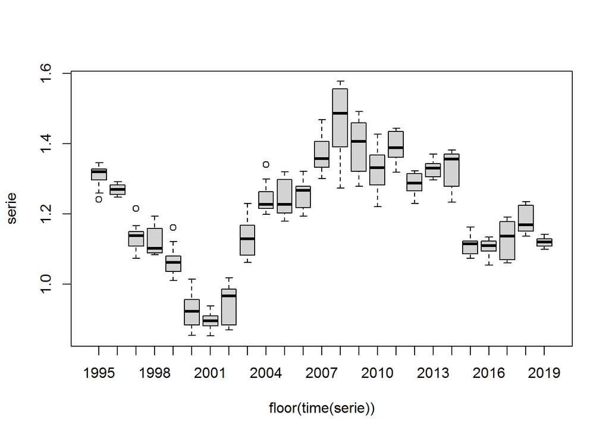

```r
boxplot(serie~floor(time(serie)))
```

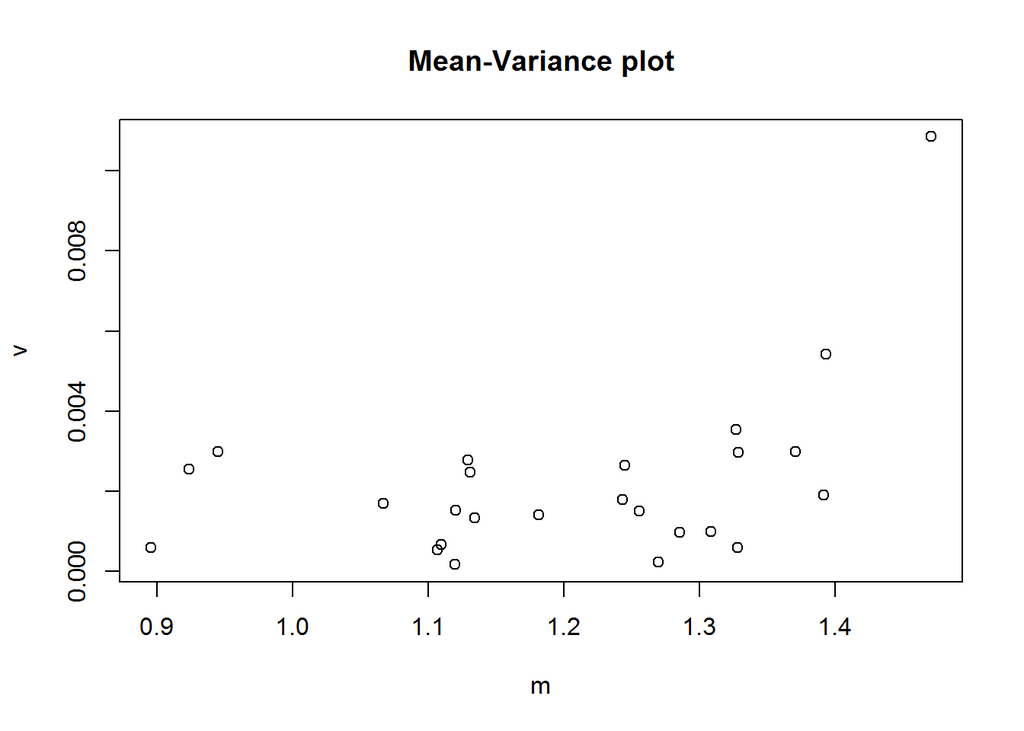

```r
#Mean-variance plot
m=apply(matrix(serie,ncol=25),2,mean)
v=apply(matrix(serie,ncol=25),2,var)
plot(v~m,main="Mean-Variance plot")
```

We consider the varianza to be constant! A log transformation not needed: it does not change variability pattern.

**Is seasonality present?**

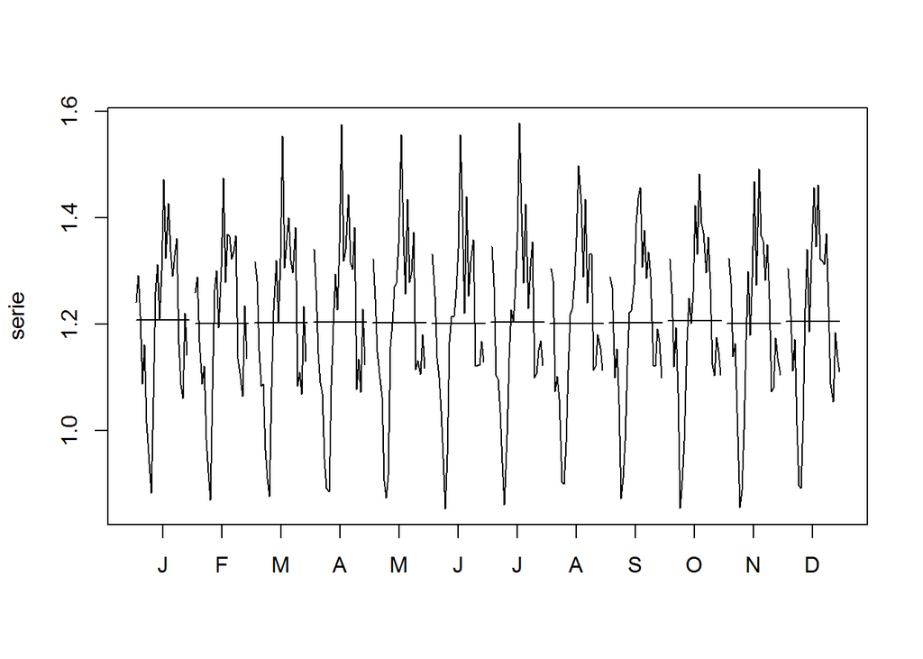

```r
monthplot(serie)
```

Nope! It does not make sense to have seasonality in an exchange-rate time series variable!

**Is the mean constant?**

Plot again the whole time series

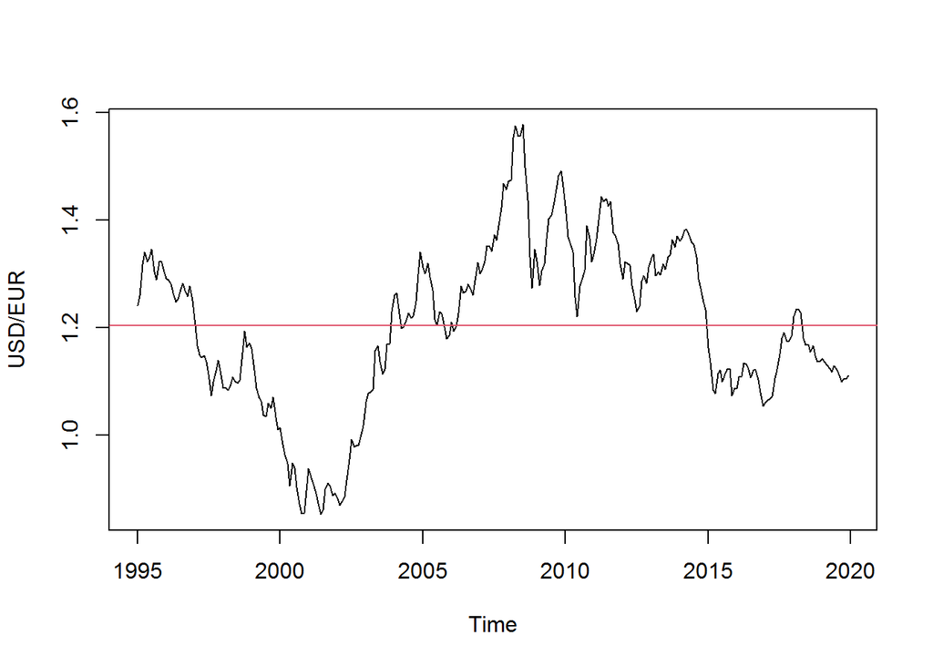

```r
plot(serie, ylab = "USD/EUR")
abline(h=mean(serie),col=2)
```

Hmmm, not clear! Let us take a look at the ACF:

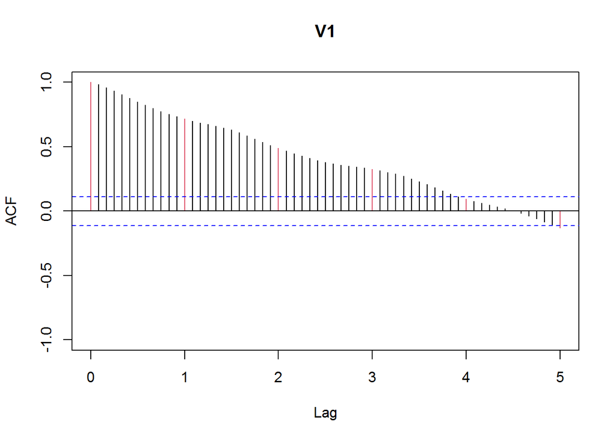

```r
acf(serie,ylim=c(-1,1),lag.max=60,col=c(2,rep(1,11)))
```

The ACF decays very slowly towards zero, suggesting non-stationarity (non-constant mean yet). At this point we need to take a decision:

- **Case 1.** Maybe not constant mean yet: we need to make it stationary by taking regular differences, or
- **Case 2.** Already constant with non-zero mean = 1.21 (reversion to the mean): assume that the EURODOL series is already stationary!!

#### **Case 1.** The EURODOL series is assumed to be non-stationary: Make the series stationary. Take a regular differentiation: d=1.

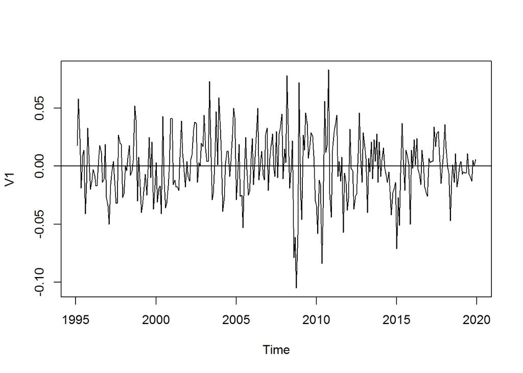

```r
d1serie=diff(serie)
plot(d1serie)
abline(h=0)
```

Now, the mean seemingly constant at zero!!!

**Is an extra differentiation needed? Take an extra differentiation and compare the variances.**

```r
var(serie,na.rm=T)
```

```
##            V1
## V1 0.02418767
```

```r
var(d1serie,na.rm=T)
```

```
##              V1
## V1 0.0007411258
```

```r
var(diff(d1serie),na.rm=T)
```

```
##             V1
## V1 0.001040396
```

Nope! We observe that with extra regular difference the variance increases…

**Is the current series already stationary? Plot the P(ACF) and decide!!**

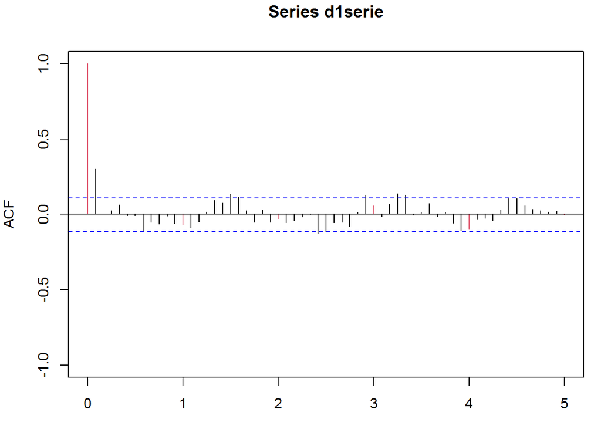

```r
par(mar = c(3,4,3,1))
acf(d1serie,ylim=c(-1,1),lag.max=60,col=c(2,rep(1,11)),na.action=na.pass, main="Series d1serie")
```

Conclusion: The differenced (d=1) exchange rate time series EURODOL (d1serie) is stationary: constant mean(=0); constant variance. The covariance structure only depends on the lags and not on the time origen.

In this case, d1serie=$W_t=(1−B)X_t$ with $μ_{W_t}=0$.

In this case, serie=$W_t=X_t$ with $μ_{W_t}=1.21$.

### III. Model Identification

#### Inspect the P(ACF) and propose >=2 models (principle of parsimony!)

#### **Case 1**. Identify possible values of p and q for the series **d1serie**

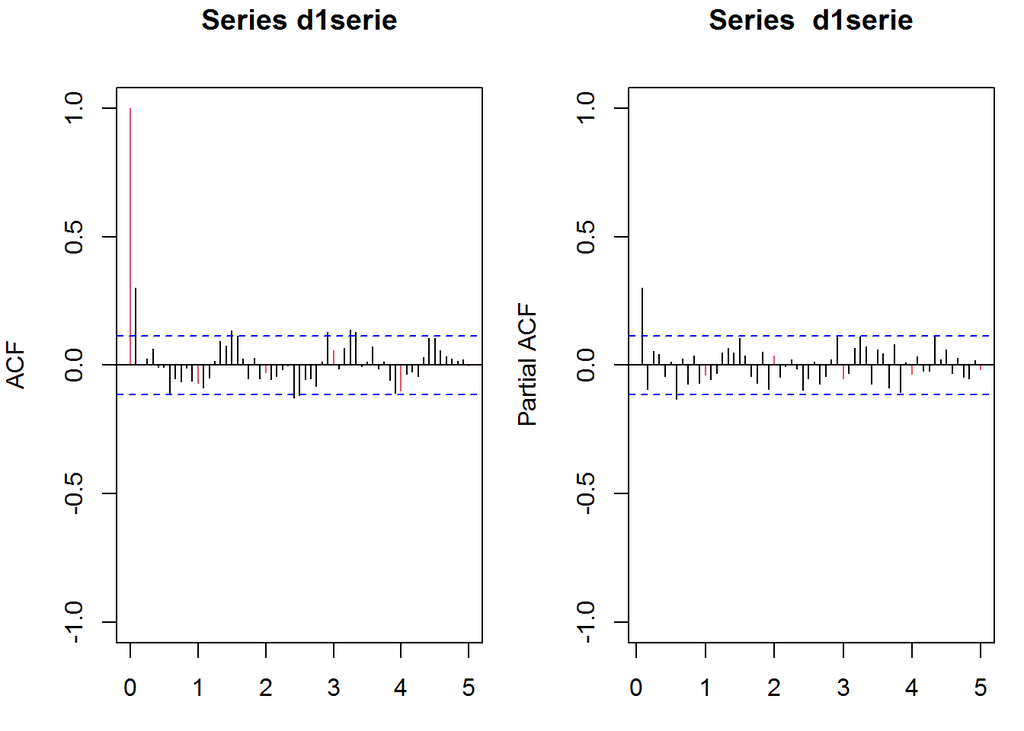

```r
par(mfrow=c(1,2), mar = c(3,4,3,1))
acf(d1serie,ylim=c(-1,1),lag.max=60,col=c(2,rep(1,11)),na.action=na.pass, main="Series d1serie")
pacf(d1serie,ylim=c(-1,1),lag.max=60,col=c(rep(1,11),2),na.action=na.pass)
```

#### Two models proposed for the stationary time series **d1serie** (W_t). Model 1: AR(1) and Model 2: MA(1).

#### **Case 2**. Identify possible values of p and q for the series: serie

Reminder: plot the time series

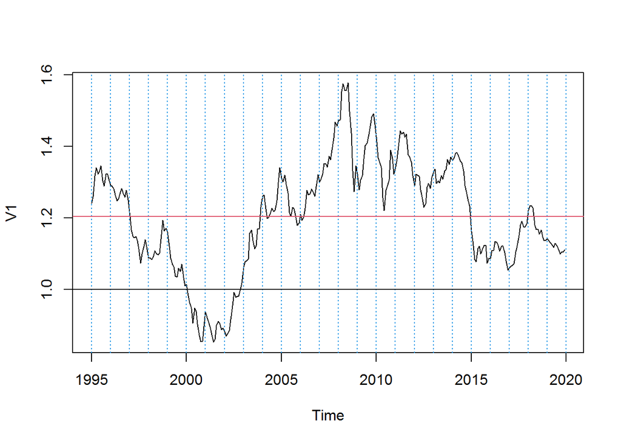

```r
plot(serie)
abline(v=1995:2020,col=4,lty=3)
abline(h=1)
abline(h=mean(serie), col=2)
```

ACF and PACF of **serie**

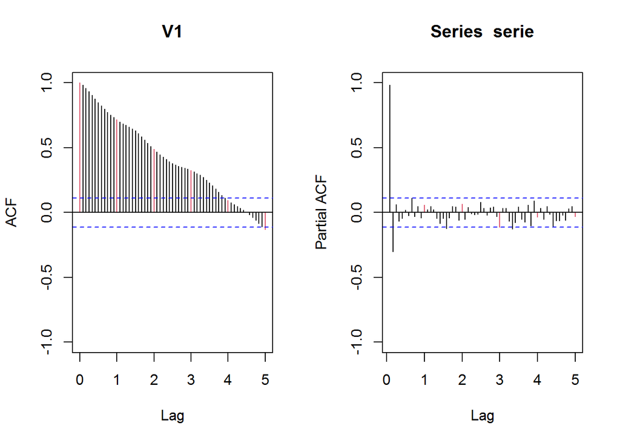

```r
par(mfrow=c(1,2))
acf(serie,ylim=c(-1,1),lag.max=60,col=c(2,rep(1,11)))
pacf(serie,ylim=c(-1,1),lag.max=60,col=c(rep(1,11),2))
```

```r
par(mfrow=c(1,1))
```

We observe an ACF that decays slowly towards zero! BUT, we force an stationary model: thus, and AR(2) identified (Model 3).

### IV. Model Estimation and validation

#### ‘Load’ the function ‘validation’: used later

```r
#################Validation#################################
validation=function(model,dades){
  s=frequency(get(model$series))
  resid=model$residuals
  par(mfrow=c(2,2),mar=c(3,3,3,3))
  #Residuals plot
  plot(resid,main="Residuals")
  abline(h=0)
  abline(h=c(-3*sd(resid),3*sd(resid)),lty=3,col=4)
  #Square Root of absolute values of residuals (Homocedasticity)
  scatter.smooth(sqrt(abs(resid)),main="Square Root of Absolute residuals",
                 lpars=list(col=2))

  #Normal plot of residuals
  qqnorm(resid)
  qqline(resid,col=2,lwd=2)

  ##Histogram of residuals with normal curve
  hist(resid,breaks=20,freq=F)
  curve(dnorm(x,mean=mean(resid),sd=sd(resid)),col=2,add=T)


  #ACF & PACF of residuals
  par(mfrow=c(1,2))
  acf(resid,ylim=c(-1,1),lag.max=60,col=c(2,rep(1,s-1)),lwd=1)
  pacf(resid,ylim=c(-1,1),lag.max=60,col=c(rep(1,s-1),2),lwd=1)
  par(mfrow=c(1,1))

  #ACF & PACF of square residuals
  par(mfrow=c(1,2))
  acf(resid^2,ylim=c(-1,1),lag.max=60,col=c(2,rep(1,s-1)),lwd=1)
  pacf(resid^2,ylim=c(-1,1),lag.max=60,col=c(rep(1,s-1),2),lwd=1)
  par(mfrow=c(1,1))

  #Ljung-Box p-values
  par(mar=c(2,2,1,1))
  tsdiag(model,gof.lag=7*s)
  cat("\n--------------------------------------------------------------------\n")
  print(model)

  #Stationary and Invertible
  cat("\nModul of AR Characteristic polynomial Roots: ",
      Mod(polyroot(c(1,-model$model$phi))),"\n")
  cat("\nModul of MA Characteristic polynomial Roots: ",
      Mod(polyroot(c(1,model$model$theta))),"\n")

  #Model expressed as an MA infinity (psi-weights)
  psis=ARMAtoMA(ar=model$model$phi,ma=model$model$theta,lag.max=36)
  names(psis)=paste("psi",1:36)
  cat("\nPsi-weights (MA(inf))\n")
  cat("\n--------------------\n")
  print(psis[1:20])
  plot(psis[1:20], pch=16, main ="Psis-weights")
  axis(1, 1:20)

  #Model expressed as an AR infinity (pi-weights)
  pis=-ARMAtoMA(ar=-model$model$theta,ma=-model$model$phi,lag.max=36)
  names(pis)=paste("pi",1:36)
  cat("\nPi-weights (AR(inf))\n")
  cat("\n--------------------\n")
  print(pis[1:20])
  plot(pis[1:20], pch=16, main ="Pi-weights")
  axis(1, 1:20)

  ##Shapiro-Wilks Normality test
  print(shapiro.test(resid(mod)))

  #Sample ACF vs. Teoric ACF
  par(mfrow=c(2,2),mar=c(3,3,3,3))
  acf(dades, ylim=c(-1,1) ,lag.max=36,main="Sample ACF")

  plot(ARMAacf(model$model$phi,model$model$theta,lag.max=36),ylim=c(-1,1),
       type="h",xlab="Lag",  ylab="", main="ACF Teoric")
  abline(h=0)

  #Sample PACF vs. Teoric PACF
  pacf(dades, ylim=c(-1,1) ,lag.max=36,main="Sample PACF")

  plot(ARMAacf(model$model$phi,model$model$theta,lag.max=36, pacf=T),ylim=c(-1,1),
       type="h", xlab="Lag", ylab="", main="PACF Teoric")
  abline(h=0)
  par(mfrow=c(1,1))
}
################# Fi Validacio #################################
```

### **Case 1.** Estimation and Validation

#### Model 1

```r
(mod=arima(d1serie,order=c(1,0,0))) #Stationary AR(1)
```

```
##
## Call:
## arima(x = d1serie, order = c(1, 0, 0))
##
## Coefficients:
##          ar1  intercept
##       0.2991    -0.0004
## s.e.  0.0551     0.0021
##
## sigma^2 estimated as 0.0006722:  log likelihood = 667.77,  aic = -1329.55
```

```r
(mod=arima(serie,order=c(1,1,0)))   #Non-stationary ARIMA(1,1,0) model for serie
```

```
##
## Call:
## arima(x = serie, order = c(1, 1, 0))
##
## Coefficients:
##          ar1
##       0.2993
## s.e.  0.0551
##
## sigma^2 estimated as 0.0006723:  log likelihood = 667.76,  aic = -1331.51
```

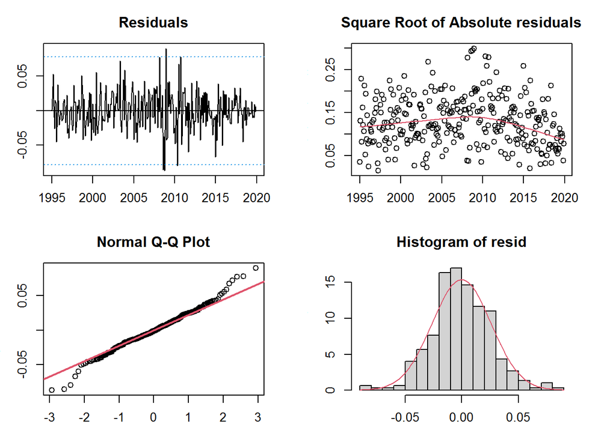

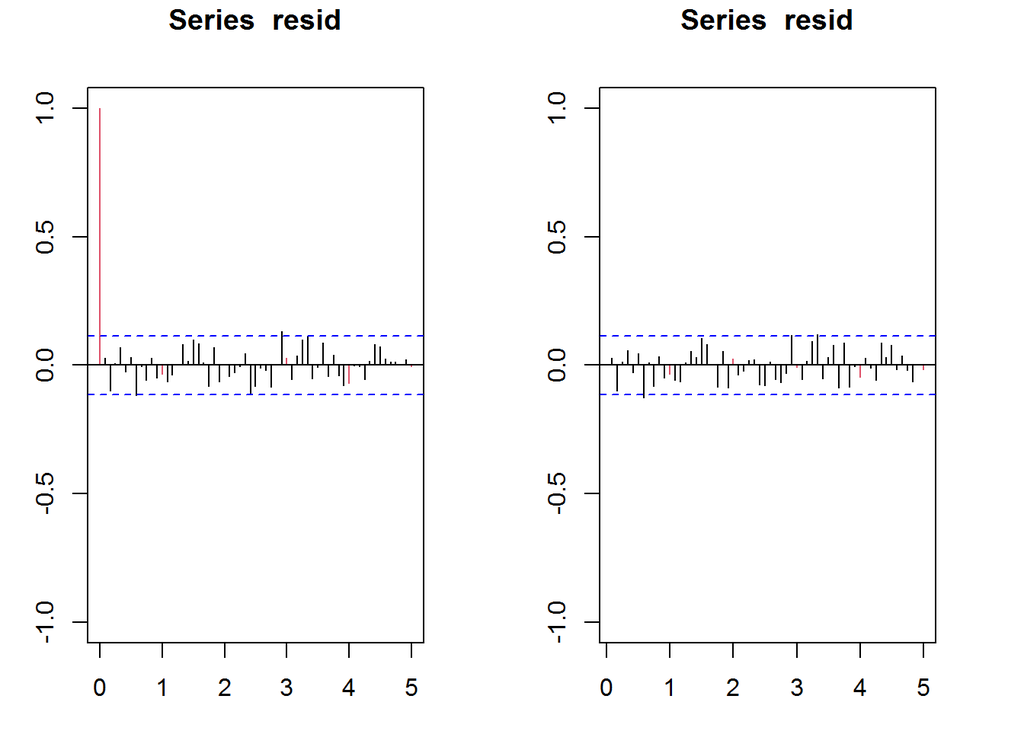

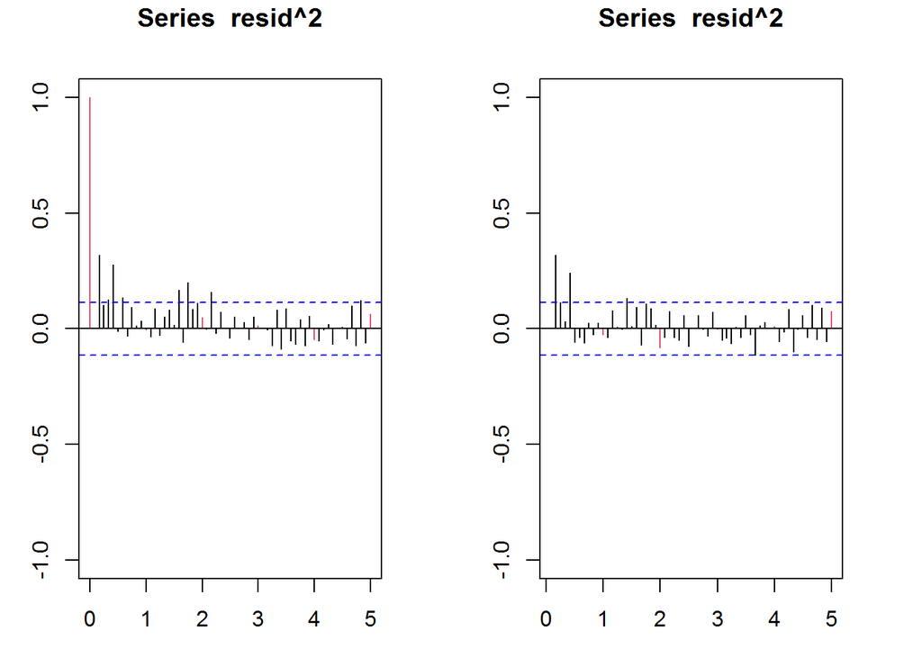

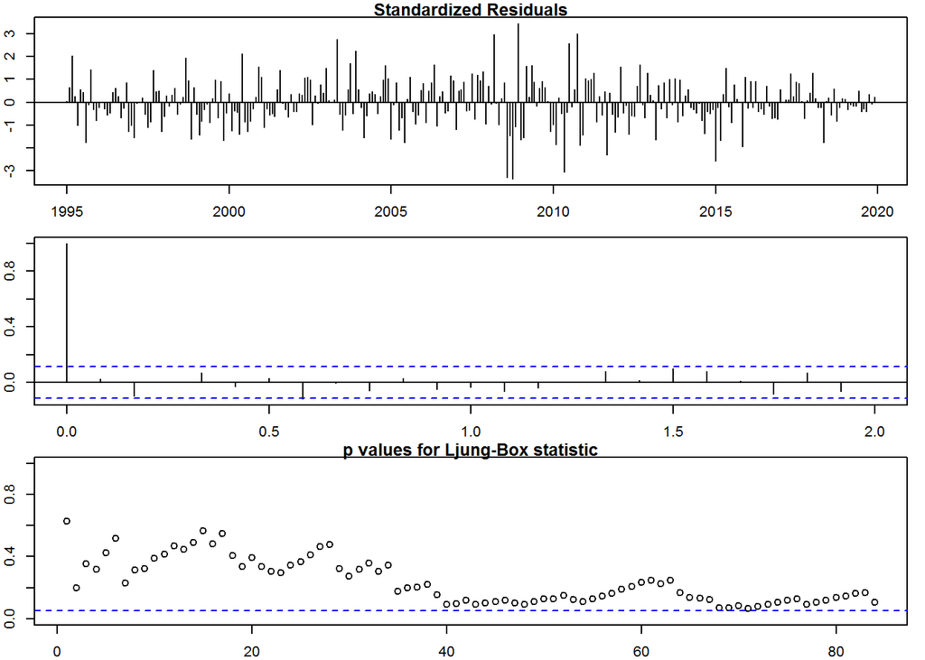

```
##
## --------------------------------------------------------------------
##
## Call:
## arima(x = serie, order = c(1, 1, 0))
##
## Coefficients:
##          ar1
##       0.2993
## s.e.  0.0551
##
## sigma^2 estimated as 0.0006723:  log likelihood = 667.76,  aic = -1331.51
##
## Modul of AR Characteristic polynomial Roots:  3.341091
##
## Modul of MA Characteristic polynomial Roots:
##
## Psi-weights (MA(inf))
##
## --------------------
##        psi 1        psi 2        psi 3        psi 4        psi 5        psi 6
## 2.993034e-01 8.958255e-02 2.681236e-02 8.025032e-03 2.401920e-03 7.189028e-04
##        psi 7        psi 8        psi 9       psi 10       psi 11       psi 12
## 2.151701e-04 6.440115e-05 1.927548e-05 5.769218e-06 1.726747e-06 5.168213e-07
##       psi 13       psi 14       psi 15       psi 16       psi 17       psi 18
## 1.546864e-07 4.629817e-08 1.385720e-08 4.147507e-09 1.241363e-09 3.715443e-10
##       psi 19       psi 20
## 1.112045e-10 3.328388e-11
```

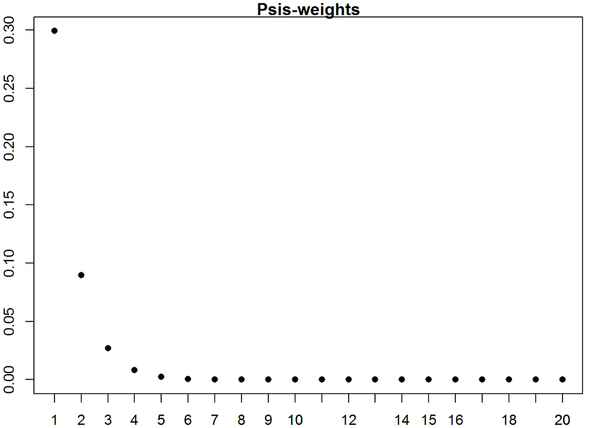

```
##
## Pi-weights (AR(inf))
##
## --------------------
##      pi 1      pi 2      pi 3      pi 4      pi 5      pi 6      pi 7      pi 8
## 0.2993034 0.0000000 0.0000000 0.0000000 0.0000000 0.0000000 0.0000000 0.0000000
##      pi 9     pi 10     pi 11     pi 12     pi 13     pi 14     pi 15     pi 16
## 0.0000000 0.0000000 0.0000000 0.0000000 0.0000000 0.0000000 0.0000000 0.0000000
##     pi 17     pi 18     pi 19     pi 20
## 0.0000000 0.0000000 0.0000000 0.0000000
```

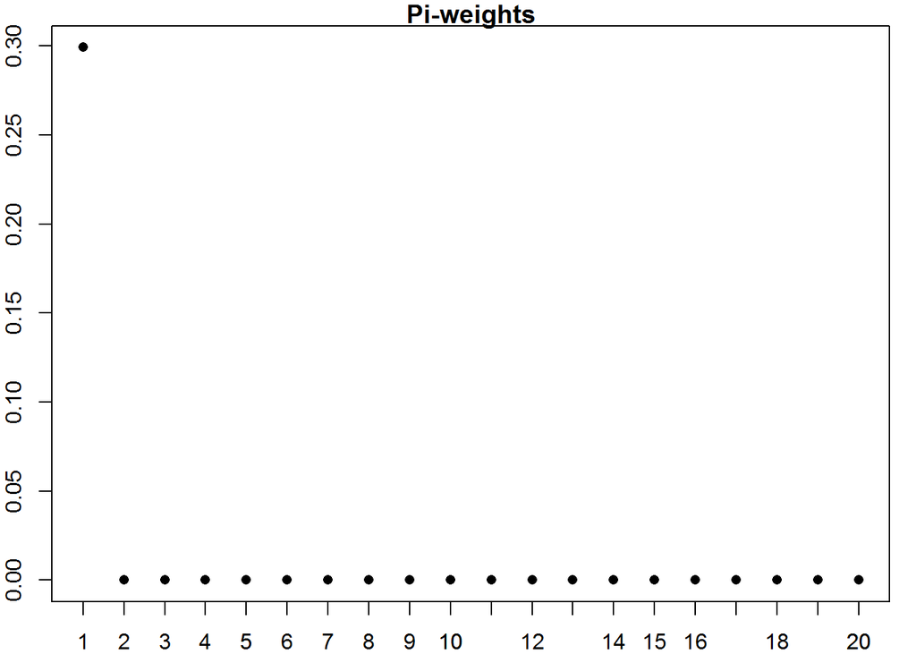

```
##
##  Shapiro-Wilk normality test
##
## data:  resid(mod)
## W = 0.98776, p-value = 0.01223
```

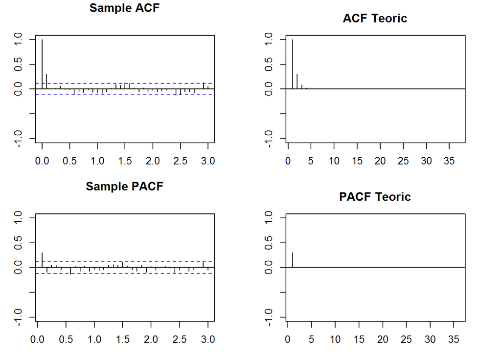

```r
dades=d1serie
model=mod
validation(model,dades)
```

**Model 1:** ARIMA(1,1,0) $(1-0.2993B)(1-B)X_t=Z_t \qquad Z_t\sim WN(0,\sigma_Z^2=0.0006723)$

#### Model 2

```r
(mod=arima(d1serie,order=c(0,0,1))) #Stationary MA(1) model for d1serie
```

```
##
## Call:
## arima(x = d1serie, order = c(0, 0, 1))
##
## Coefficients:
##          ma1  intercept
##       0.3251     -4e-04
## s.e.  0.0529      2e-03
##
## sigma^2 estimated as 0.0006659:  log likelihood = 669.18,  aic = -1332.37
```

```r
(mod=arima(serie,order=c(0,1,1))) #Non-stationary ARIMA(0,1,1) model for serie
```

```
##
## Call:
## arima(x = serie, order = c(0, 1, 1))
##
## Coefficients:
##          ma1
##       0.3252
## s.e.  0.0529
##
## sigma^2 estimated as 0.000666:  log likelihood = 669.16,  aic = -1334.32
```

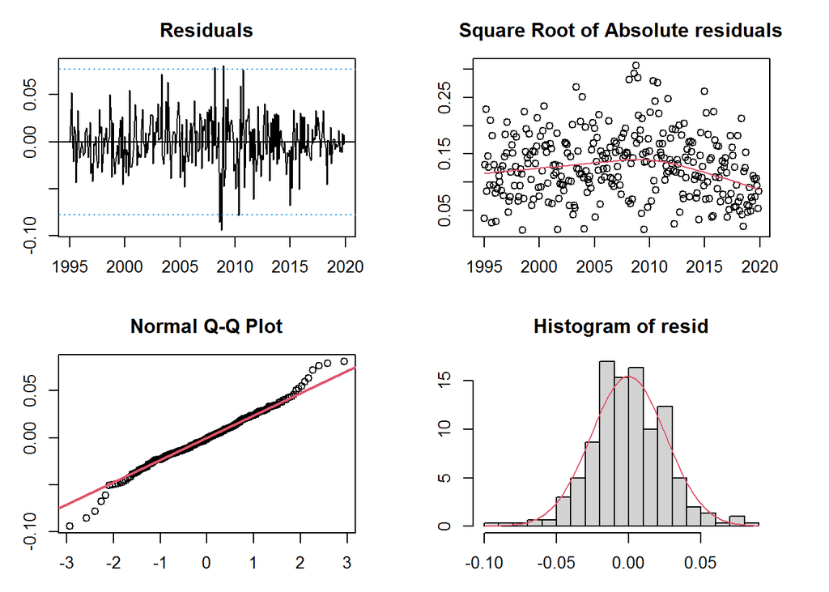

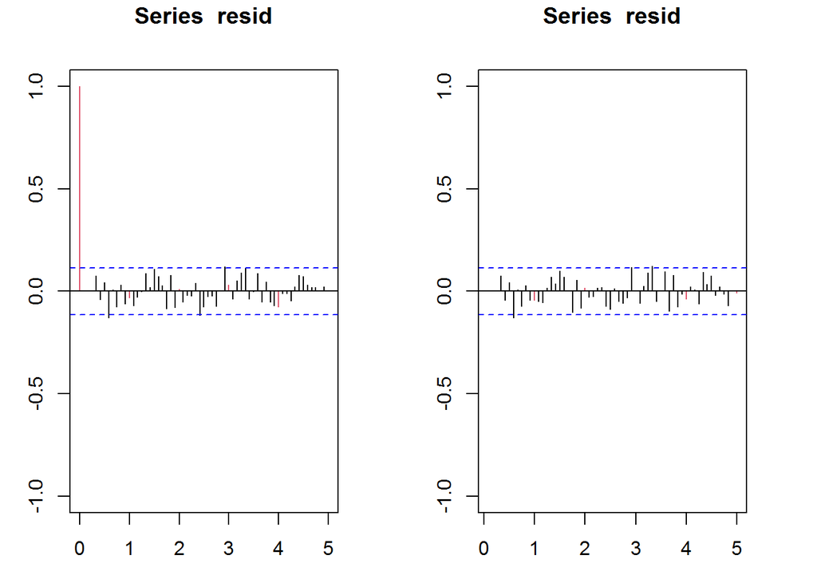

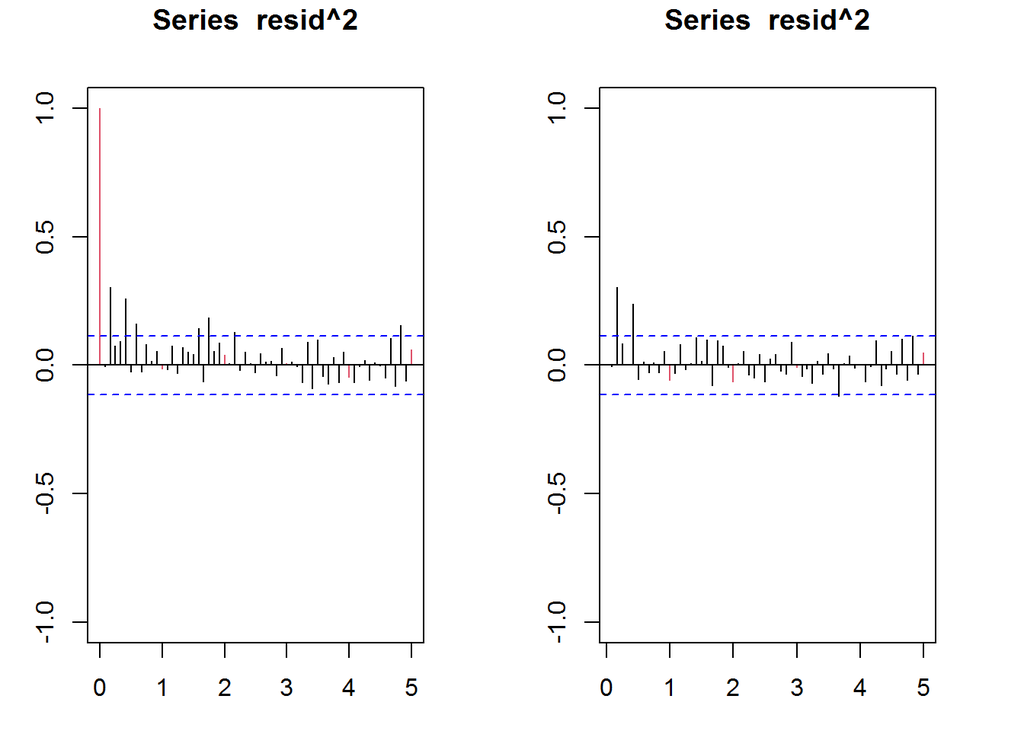

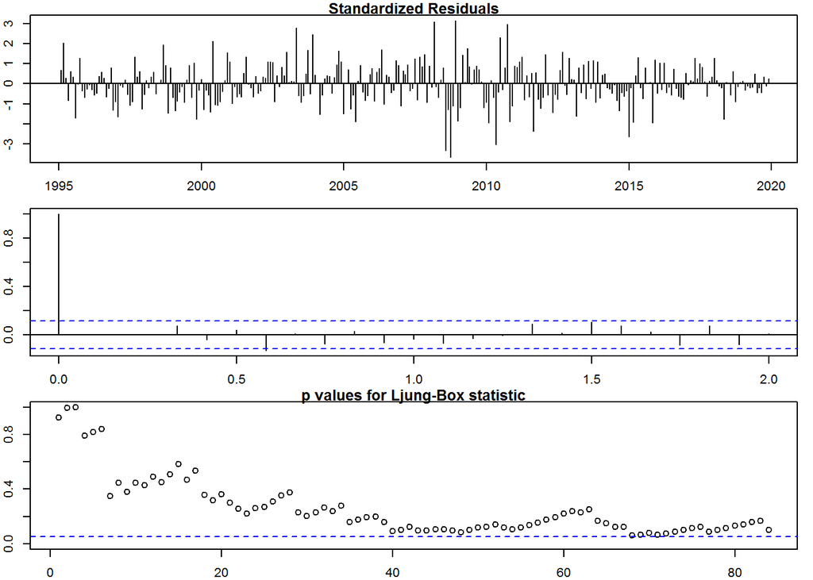

```
##
## --------------------------------------------------------------------
##
## Call:
## arima(x = serie, order = c(0, 1, 1))
##
## Coefficients:
##          ma1
##       0.3252
## s.e.  0.0529
##
## sigma^2 estimated as 0.000666:  log likelihood = 669.16,  aic = -1334.32
##
## Modul of AR Characteristic polynomial Roots:
##
## Modul of MA Characteristic polynomial Roots:  3.074898
##
## Psi-weights (MA(inf))
##
## --------------------
##    psi 1    psi 2    psi 3    psi 4    psi 5    psi 6    psi 7    psi 8
## 0.325214 0.000000 0.000000 0.000000 0.000000 0.000000 0.000000 0.000000
##    psi 9   psi 10   psi 11   psi 12   psi 13   psi 14   psi 15   psi 16
## 0.000000 0.000000 0.000000 0.000000 0.000000 0.000000 0.000000 0.000000
##   psi 17   psi 18   psi 19   psi 20
## 0.000000 0.000000 0.000000 0.000000
```

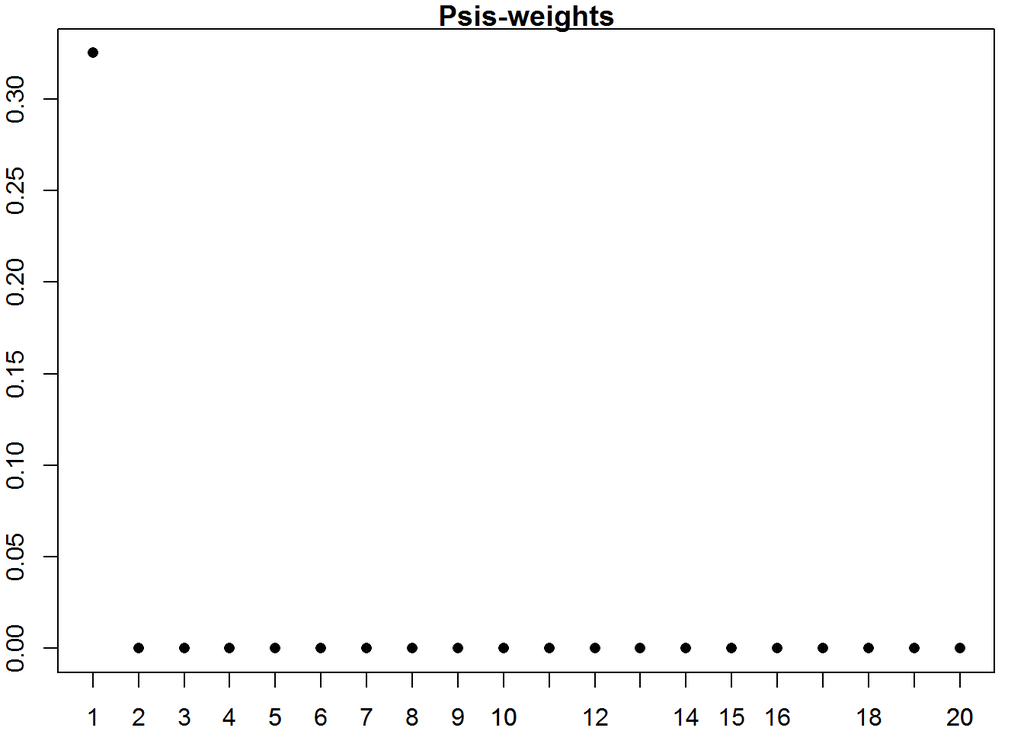

```
##
## Pi-weights (AR(inf))
##
## --------------------
##          pi 1          pi 2          pi 3          pi 4          pi 5
##  3.252140e-01 -1.057642e-01  3.439600e-02 -1.118606e-02  3.637864e-03
##          pi 6          pi 7          pi 8          pi 9         pi 10
## -1.183085e-03  3.847557e-04 -1.251280e-04  4.069337e-05 -1.323406e-05
##         pi 11         pi 12         pi 13         pi 14         pi 15
##  4.303901e-06 -1.399689e-06  4.551985e-07 -1.480369e-07  4.814369e-08
##         pi 16         pi 17         pi 18         pi 19         pi 20
## -1.565701e-08  5.091878e-09 -1.655950e-09  5.385383e-10 -1.751402e-10
```

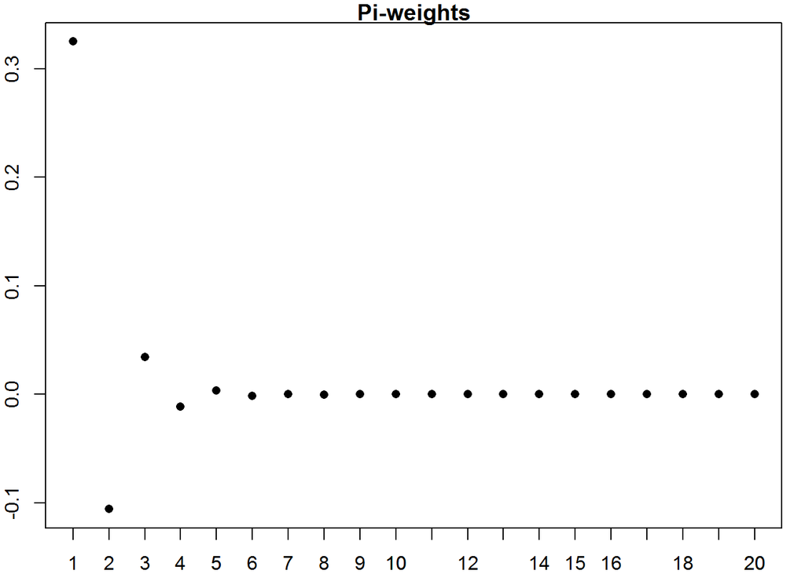

```
##
##  Shapiro-Wilk normality test
##
## data:  resid(mod)
## W = 0.98674, p-value = 0.007403
```

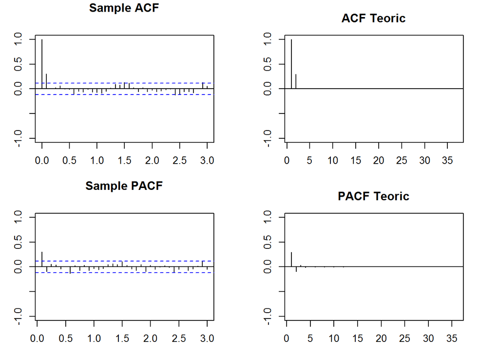

```r
dades=d1serie
model=mod
validation(model,dades)
```

**Model 2:** ARIMA(0,1,1) $(1-B)X_t=(1+0.3252B)Z_t \qquad Z_t\sim WN(0,\sigma_Z^2=0.000666)$

### **Case 2.** Estimation and Validation

#### Model 3

```r
#Stationary AR(2) model for serie; intercept <> 0
(mod=arima(serie,order=c(2,0,0)))
```

```
##
## Call:
## arima(x = serie, order = c(2, 0, 0))
##
## Coefficients:
##          ar1      ar2  intercept
##       1.2868  -0.3084     1.1965
## s.e.  0.0547   0.0548     0.0624
##
## sigma^2 estimated as 0.000661:  log likelihood = 670.78,  aic = -1333.56
```

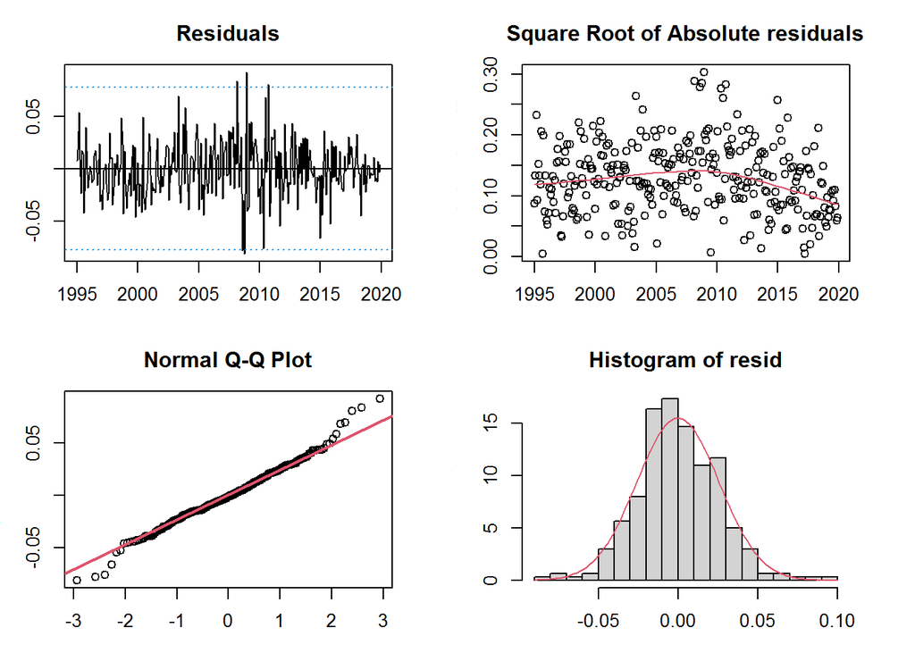

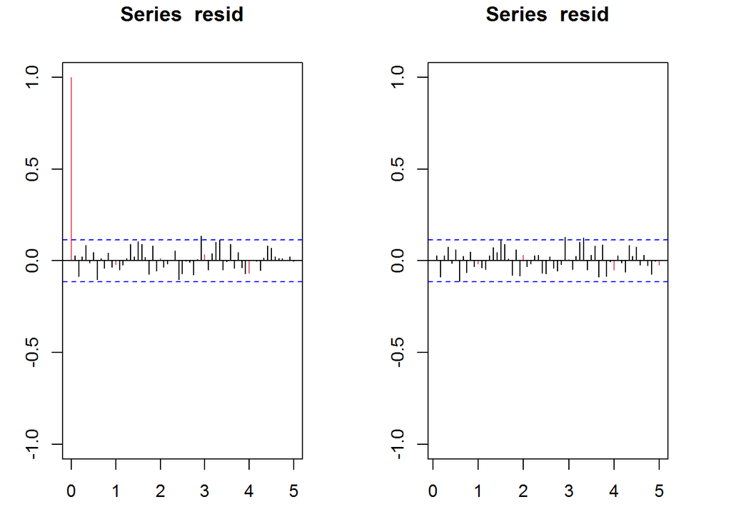

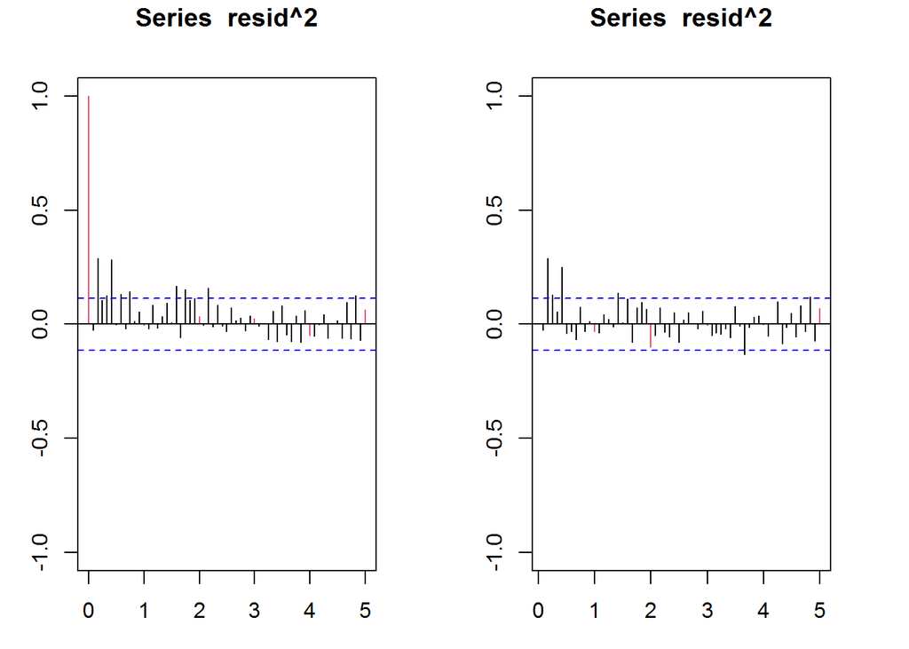

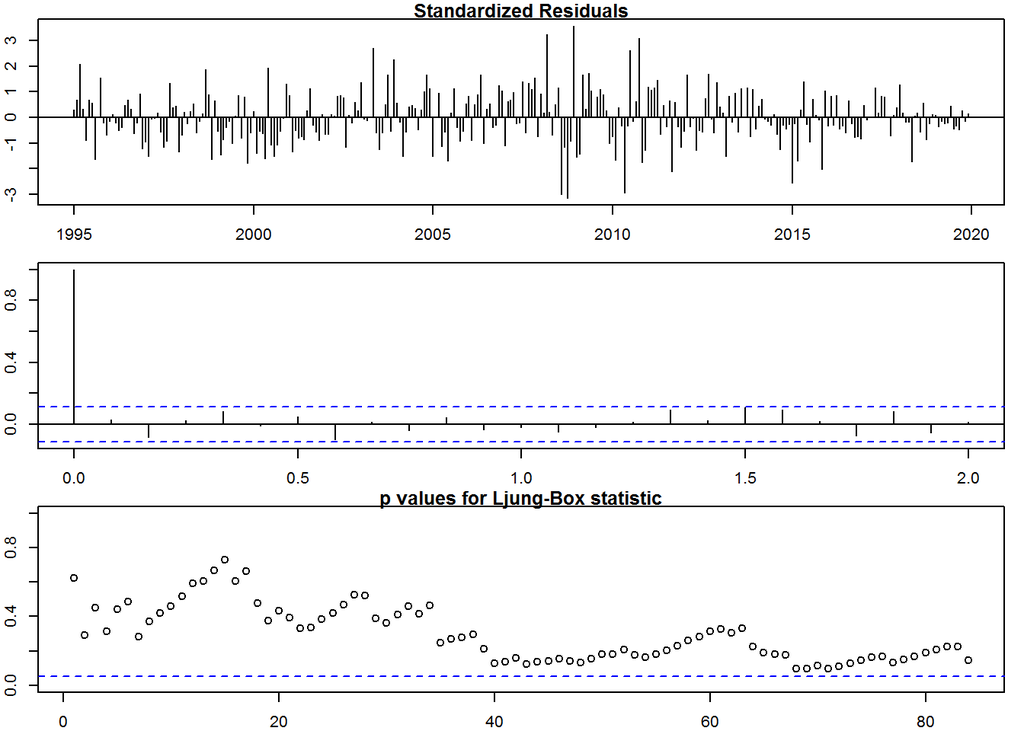

```
##
## --------------------------------------------------------------------
##
## Call:
## arima(x = serie, order = c(2, 0, 0))
##
## Coefficients:
##          ar1      ar2  intercept
##       1.2868  -0.3084     1.1965
## s.e.  0.0547   0.0548     0.0624
##
## sigma^2 estimated as 0.000661:  log likelihood = 670.78,  aic = -1333.56
##
## Modul of AR Characteristic polynomial Roots:  1.032871 3.138952
##
## Modul of MA Characteristic polynomial Roots:
##
## Psi-weights (MA(inf))
##
## --------------------
##     psi 1     psi 2     psi 3     psi 4     psi 5     psi 6     psi 7     psi 8
## 1.2867527 1.3472935 1.3367489 1.3045075 1.2662731 1.2270194 1.1883026 1.1505910
##     psi 9    psi 10    psi 11    psi 12    psi 13    psi 14    psi 15    psi 16
## 1.1140073 1.0785648 1.0442429 1.0110110 0.9788360 0.9476846 0.9175246 0.8883244
##    psi 17    psi 18    psi 19    psi 20
## 0.8600535 0.8326824 0.8061823 0.7805255
```

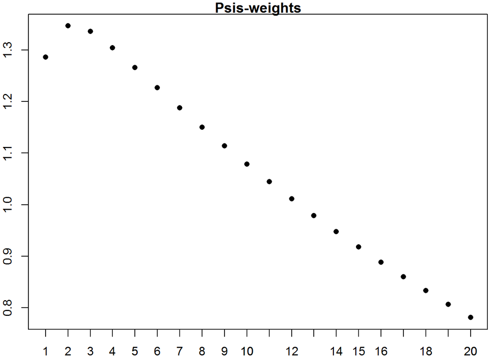

```
##
## Pi-weights (AR(inf))
##
## --------------------
##       pi 1       pi 2       pi 3       pi 4       pi 5       pi 6       pi 7
##  1.2867527 -0.3084389  0.0000000  0.0000000  0.0000000  0.0000000  0.0000000
##       pi 8       pi 9      pi 10      pi 11      pi 12      pi 13      pi 14
##  0.0000000  0.0000000  0.0000000  0.0000000  0.0000000  0.0000000  0.0000000
##      pi 15      pi 16      pi 17      pi 18      pi 19      pi 20
##  0.0000000  0.0000000  0.0000000  0.0000000  0.0000000  0.0000000
```

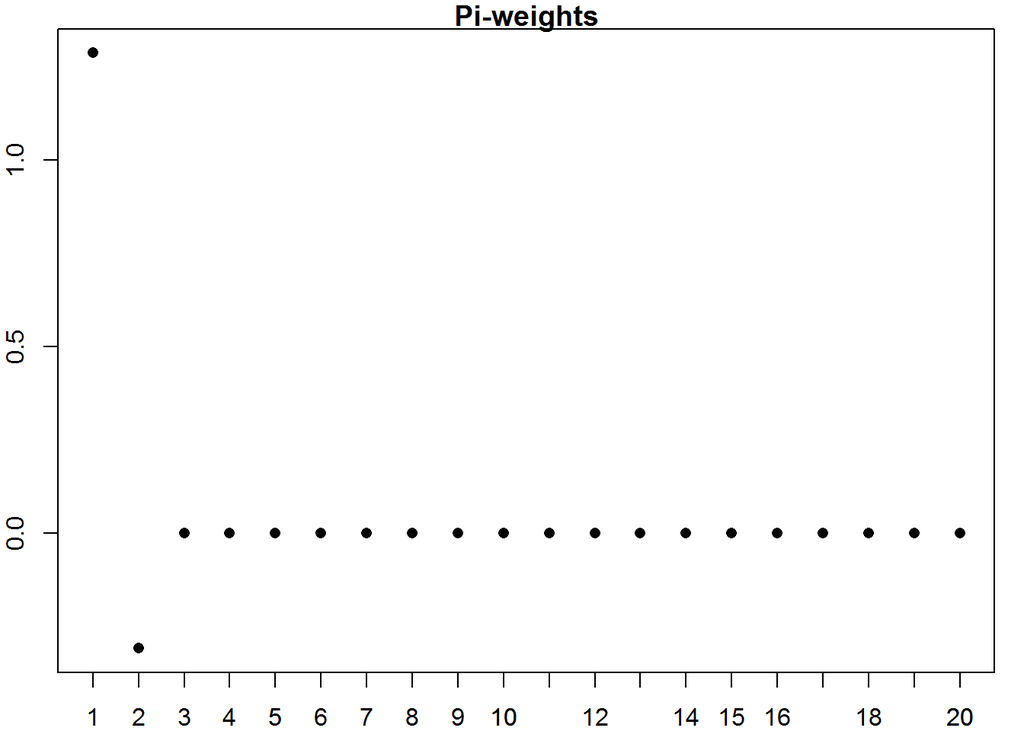

```
##
##  Shapiro-Wilk normality test
##
## data:  resid(mod)
## W = 0.98853, p-value = 0.01803
```

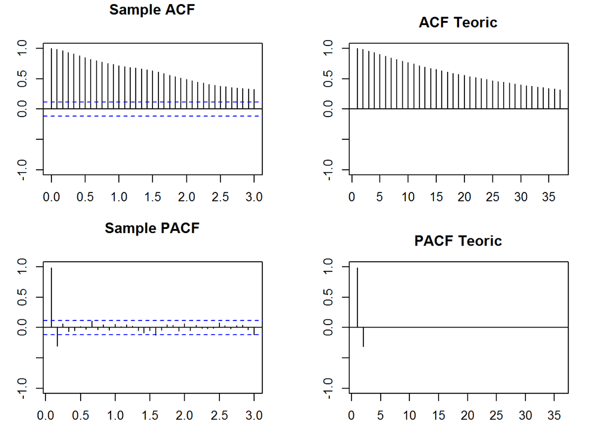

```r
dades=serie
model=mod
validation(model,dades)
```

**Model 3:** ARIMA(2,0,0) $(1-1.2868B+0.3084B^2)(X_t-1.1965)=Z_t \qquad Z_t\sim WN(0,\sigma_Z^2=0.000661)$

### V. Sum Up Adequacy Measures

Recall:

Model 1: $(1-0.2993B)(1-B)X_t=Z_t \Rightarrow (1-1.2993B+0.2993B^2)X_t=Z_t$

Model 3: $(1-1.2868B+0.3084B^2)(X_t-1.1965)=Z_t \Rightarrow (1-1.2868B+0.3084B^2)X_t=0.0258444+Z_t$